# Lecture 11: Sampling

Data Analysis for Psychology in R 1

Tom Booth

Click for slides

## Course feedback

- Thank-you for all the course feedback.
  - Lots of positives and lots of things to think about developing.
- Some quick changes for the rest of this year:
  - Slight changes to labs
  - Improve the consistency of lecture and lab code
  - Fuller code explanations
  - Add links to more detailed statistical material

## Administrative matters

- Times and locations for both lectures and labs have changed.
- Please check carefully.
- If you can not make your new lab, let us know.

## Concepts to carry forward

- Data can be of different types.
- Dependent on type (continuous vs. categorical), we can visualise and describe the distribution of data differently.
- When thinking about events (“things happening”) we can assign probabilities to the event.
- We can then define a probability distribution that describes the probability of all possible events.

## In Psych Stats

- In psychology, we design a study, to calculate a value that carries some meaning.
  - Reaction time of one group vs another.
- Given it has meaning based on the study design, we want to know something about the number:
  - Is it unusual or not?
- This is the task for the next 4-5 weeks.

## Today

- We will talk about populations, samples and sampling.
- Basic concepts of sampling may seem simple and intuitive
- But these concepts are very useful when we start talking about statistical inference
  - Statistical inference = how we make decisions about statistics we calculate.

## Learning objectives

- Understand the concept principles sampling from populations.
- Be familiar with the specific statistical terminology for sampling.
- Understand the concept of a sampling distribution.

## A question

- Suppose I wanted to know the proportion of UG students at the University of Edinburgh were born in Scotland?
  - In stats talk, all UG at the UoE are our **population**.
  - The proportion of Scottish students is the **population parameter** (the thing we are interested in).
- What is the best way to find this out exactly?
- What else might we do?

## Let’s try

- Sample the class

## Sampling distribution (1)

- What we have just drawn is a **sampling distribution** for the proportion of Scottish students
  - This is just a histogram.
  - Each data point is a guess based on some data of the proportion of students that are Scottish at UoE.

## Parameter vs point-estimate

- Key idea:
  - There is population parameter (proportion of Scottish students at UoE) we are interested in.
  - We can draw a sample, and calculate this proportion (statistic) in the sample.
  - In a single sample, this **point-estimate** is our best guess at the population parameter.

## 2017/18 actual proportion

| Scottish | n | Freq |
| --- | --- | --- |
| No | 13926 | 0.54 |
| Yes | 12025 | 0.46 |

- To save time, we are going to automate the process of looking at samples from now on.
- So let’s look at a few more examples.

## Visualizing sampling distributions

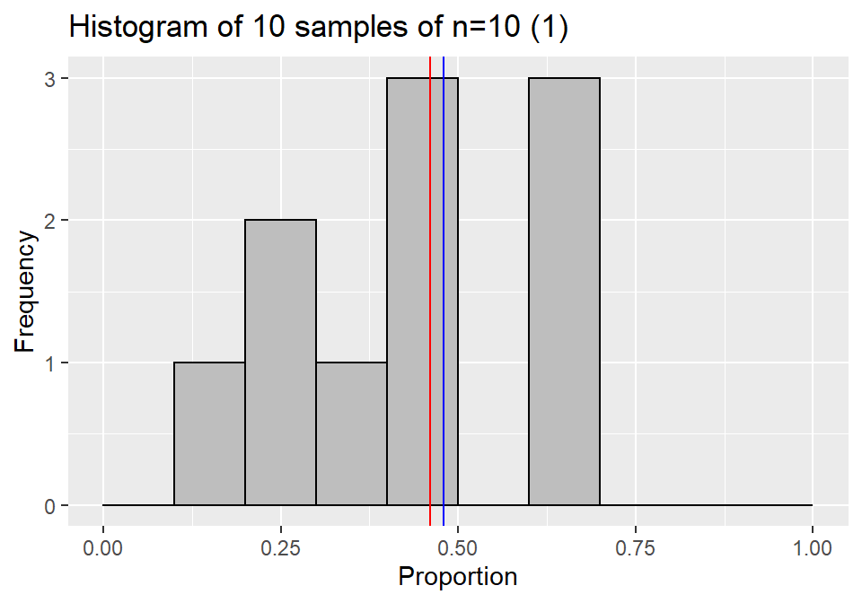

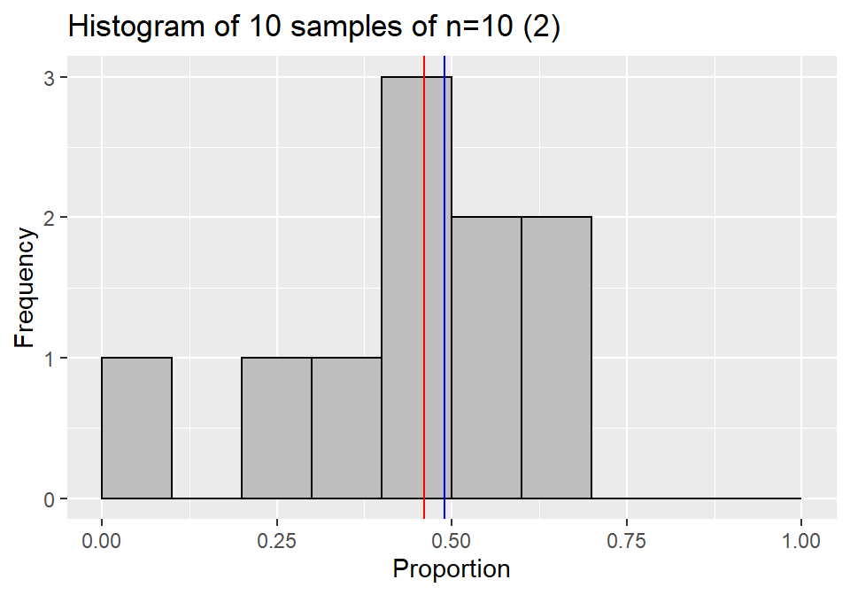

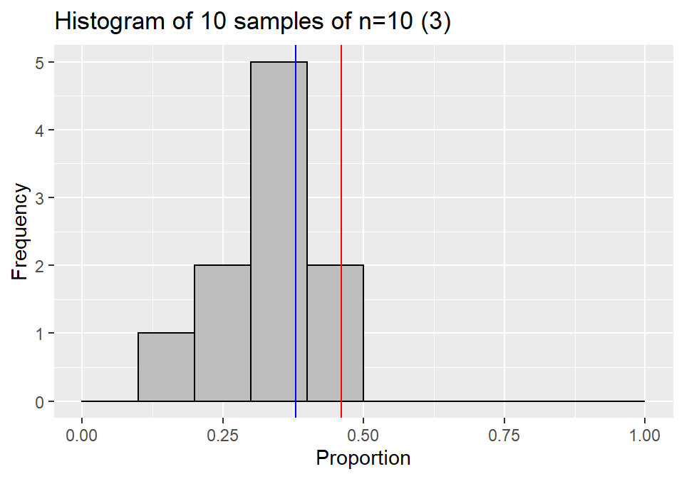

## Sampling distributions (2)

- We have just calculated three sampling distributions
- Each of these look different.
- Each sampling distribution is characterising the **sampling variability** in our **estimate** of the **parameter** of interest (proportion of Scottish students at UoE).

## More samples

- So far we have just taken 10 samples.
- What if we took more?

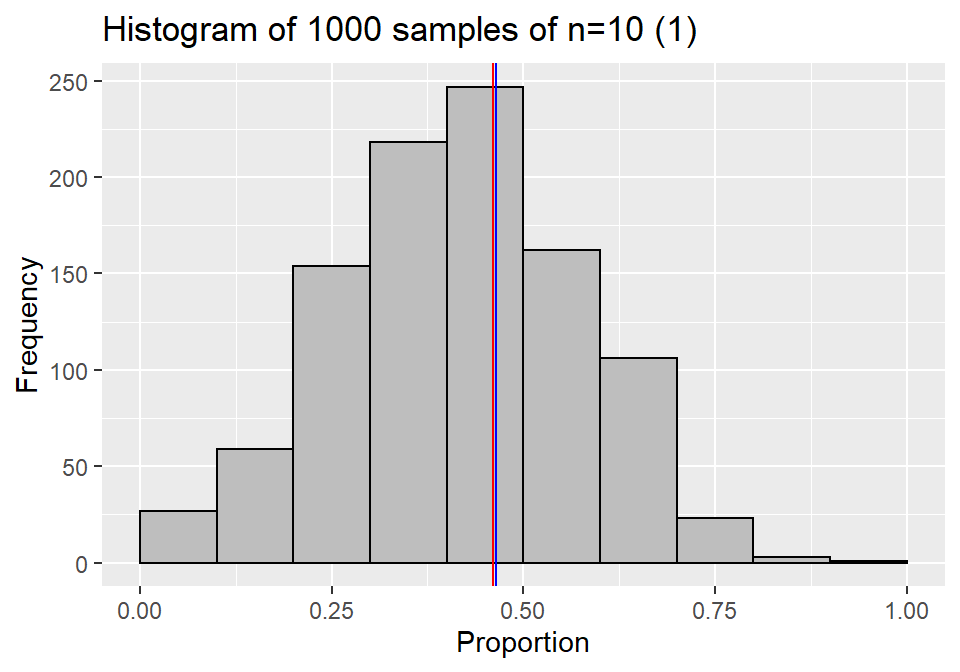

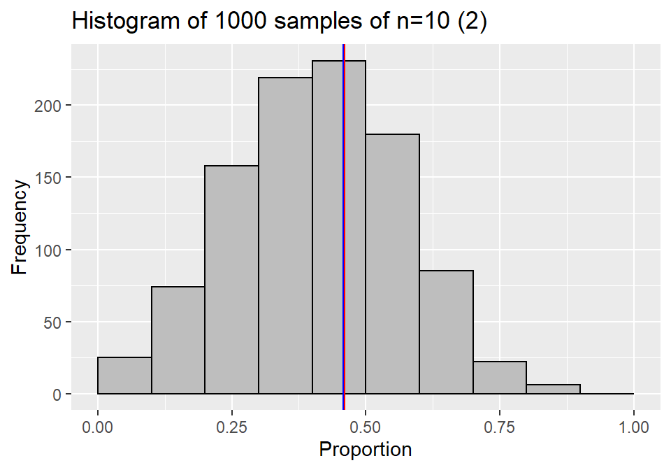

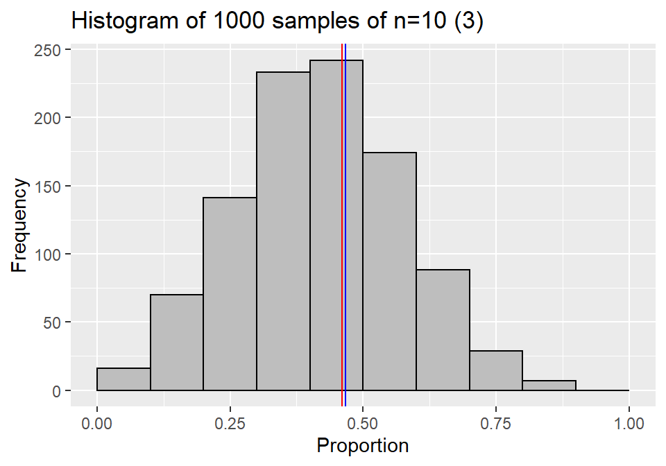

- What do you notice about the plots on the last three slides?

## Frequency = probability

- At this point lets pause and remember some things from probability.
- When we spoke about probability, we spoke about the relation to frequency.
- If something did not happen very often, it has a lower probability.
  - Now think about our sampling distributions of the proportion of Scottish students

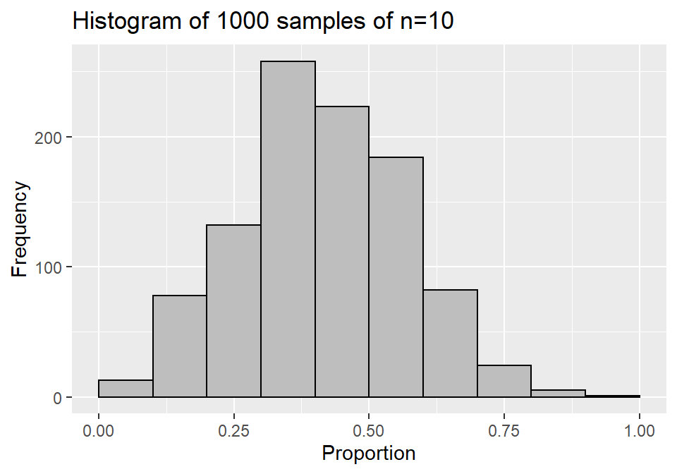

## Bigger samples

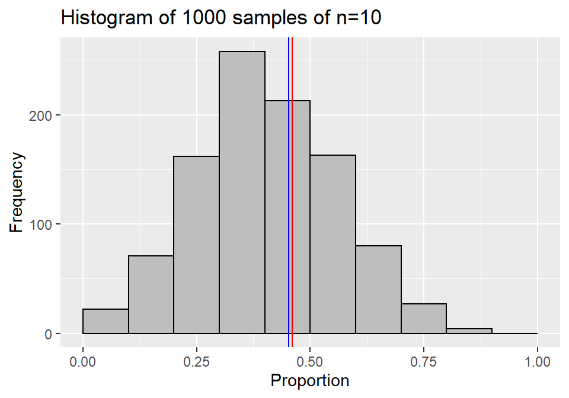

- So above is a frequency distribution for $n$=10.
- Let’s see what happens when we make $n$ bigger.

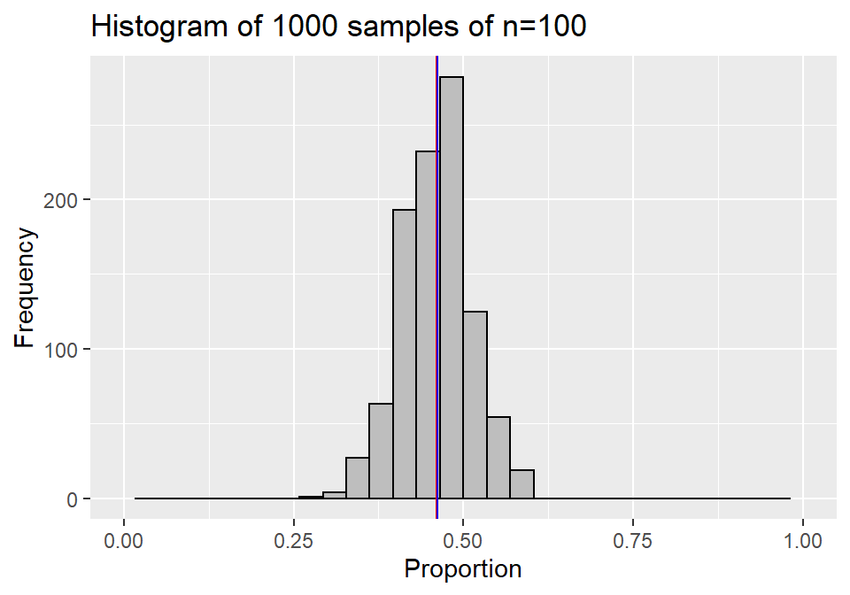

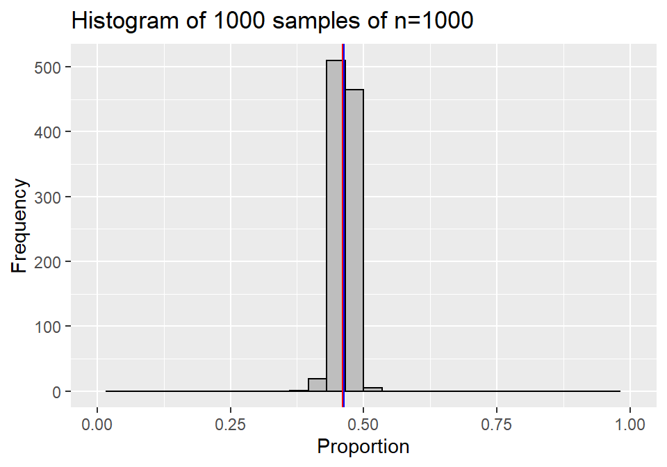

- What do you notice about the last three slides?

## What does it mean to be narrow?

- Remember: frequency distributions are characterising the variability in sample estimates.
- Variability can be thought of as the spread in data/plots.
- So as we increase $n$ we are getting….
- To think about this in probability language, as $n$ increases, the probability of observing an estimate in a sample that is a long way from the population parameter (here 0.46) decreases (becomes less probable).
- So when we have large samples, our estimates from those samples are likely to be closer to the population value.
  - This is a good thing.

## Standard error

- We can formally calculate the “narrowness” of a sampling distribution.
  - This is essentially calculating the standard deviation (as we have done before) of the sampling distribution.
  - Or at least approximating it!
- In the context of sampling distributions, this is called the **standard error**

## Mean & SE of sampling distribution

- Mean of the sampling distribution is close to the population parameter.
  - Even with a small number of samples.
- As the number of samples increases, the sampling distribution approaches a normal distribution.
  - Point-estimates pile up around the population value.
- As the n per sample increases, the SE of the sampling distribution decreases (becomes narrower).
  - With large n, all our point-estimates are closer to the population parameter.

## Central Limit Theorem

- What we have seen throughout this lecture is a demonstration of an important concept in statistics - namely, **central limit theorem**.
- The central limit theorem (roughly) states that when estimates of sample means are based on increasingly large samples ($n$), the sampling distribution of means becomes more normal (symmetric), and narrower (quantified by the standard error).

## Key terminology

- **Census**: process of asking every member of a population.
- **Sampling**: process of selecting subsets of populations.
- **Population**: the complete set of units of interest.
- **Sample**: A subset of the population
- **Parameter**: value of of interest in the population.
- **Point estimate**: our “best guess” at the parameter of interest from a sample.
- **Sampling distribution**: the distribution of estimates of the population parameter.
- **Standard error**: quantification of the variation in estimates.

## Features of samples

- Is our sample…
  - Biased?
  - Representative?
  - Random?

## Good samples

- If a sample of $n$ is drawn at random, it will be unbiased and representative of $N$
- Our point estimates from such samples will be good guesses at the population parameter.
  - Without the need for census.

## Tasks for this week…

1. Look back over any material from last term.
2. Reading: Can be found [here](https://moderndive.com/7-sampling.html)
3. Quiz 11: Semester 1 R
   - Live now.
   - Close Sunday at 17:00

## Recommendations of the week

- These will start again next week.